# Predicting Movie Success

### By: Arthur Gregorian "On my honor, as a student, I have neither given nor received unauthorized aid on this academic work."

[figure not shown]

# Background

Is it possible to predict the success of a movie based on a certain set of data points? That is the purpose of this study.

The goal of this study is to predict the success of a movie by answering the following questions:

1. Does it matter who the director is for a movie to be successful?
2. Does it matter who the actor or actress is for a movie to be successful?
3. What genre of movies are most successful?
4. How does the movie rating (PG, PG-13, R, etc) affect the success of a movie?
5. Do facebook likes determine movie success?
6. Does a successful movie have and Oscar wins or Nominations?
7. Is the IMDB score a good indicator of movie success?
   1. What variables are highly correlated with the IMDB score?
   2. Look into the number of votes used to create the score.

In order to answer these questions, we need to collect past data such as:

- Budget & Gross earnings
  - We can calculate profit from these and determine movie success with this figure.
- The director's name
- The leading actor/actress
- Movie Genre
- Movie Rating
- Facebook likes
  - to include director and actor facebook likes as well as movie facebook likes.
- Oscar wins/nominations

## Data Description

The data set in use is collected from the Internet Movie DataBase (IMDB) website. It comprises of the following data: [Data source](https://data.world/popculture/imdb-5000-movie-dataset)

The original dataset was collected in two parts:

1. The names of the movies were first collected from the-numbers.com.
2. Second, the names collected in the previous step were used to search IMDB for scraping. This method worked fine, however, upon closer inspection of the data, I found it to be a bit misleading. When searching IMDB with the movie title from the-numbers.com, it didn't always result in the feature film on the IMDB website. Sometimes, IMDB returned a TV show or video game instead and this data was scraped. This was due to the slightly different movie title across the pages.

To remedy this, I downloaded the code provided by the original author of the dataset ([source](https://github.com/sundeepblue/movie_rating_prediction/blob/master/movie/spiders/imdb_url_spider.py)) to make the following changes:

1. I first searched IMDB for all feature films and sorted the results by Gross profit.
2. Next the scraped the top 5000 search results to collect the Movie urls and titles
3. Lastly, I scarped the individual movie page in IMDB from the urls collected in step 2.
4. Additionally, I added data to show how many Oscars it had won. If the movie had no wins, I collected data on how many Oscars it was nominated for.

| Variable Name | Description |
| --- | --- |
| movie_title | Title of the Movie |
| oscar_wins | Number of Oscars won. *Note: If movie won an Oscar, the Oscar nominations are not counted. |
| oscars_nom | Number of Oscar nominated for. *Note: Nominations are only counted if the movie did not win an Oscar. |
| duration | Duration in minutes |
| director_name | Name of the Director of the Movie |
| director_facebook_likes | Number of likes of the Director on his Facebook Page |
| actor_1_name | Primary actor starring in the movie |
| actor_1_facebook_likes | Number of likes of the Actor_1 on his/her Facebook Page |
| actor_2_name | Other actor starring in the movie |
| actor_2_facebook_likes | Number of likes of the Actor_2 on his/her Facebook Page |
| actor_3_name | Other actor starring in the movie |
| actor_3_facebook_likes | Number of likes of the Actor_3 on his/her Facebook Page |
| num_user_for_reviews | Number of users who gave a review |
| num_critic_for_reviews | Number of critical reviews on imdb |
| num_voted_users | Number of people who voted for the movie |
| cast_total_facebook_likes | Total number of facebook likes of the entire cast of the movie |
| movie_facebook_likes | Number of Facebook likes in the movie page |
| plot_keywords | Keywords describing the movie plot |
| facenumber_in_poster | Number of the actor who featured in the movie poster |
| color | Film colorization. ‘Black and White’ or ‘Color’ |
| genres | Film categorization like ‘Animation’, ‘Comedy’, ‘Romance’, ‘Horror’, ‘Sci-Fi’, ‘Action’, ‘Family’ |
| title_year | The year in which the movie is released (1916:2016) |
| language | English, Arabic, Chinese, French, German, Danish, Italian, Japanese etc |
| country | Country where the movie is produced |
| content_rating | Content rating of the movie |
| aspect_ratio | Aspect ratio the movie was made in |
| movie_imdb_link | IMDB link of the movie |
| gross | Gross earnings of the movie in Dollars |
| budget | Budget of the movie in Dollars |
| imdb_score | IMDB Score of the movie on IMDB |

# Data Understanding

```python
# import packages
import csv
import pandas as pd
from IPython.display import display
from collections import Counter
import ast
import numpy as np
import seaborn as sns
import scipy.stats as stats
from pandas.tools import plotting
import matplotlib.pyplot as plt
from scipy.stats import norm
from wordcloud import WordCloud
%matplotlib inline

pd.options.display.max_columns = None

# import data
imdb = pd.read_csv("data/movie_metadata.csv")

# reorganize the data to match the order in the table above
imdb = imdb[['movie_title', 'oscar_wins', 'oscar_noms', 'duration', 'director_name', 'director_facebook_likes', 'actor_1_name', 'actor_1_facebook_likes', 'actor_2_name', 'actor_2_facebook_likes', 'actor_3_name', 'actor_3_facebook_likes', 'num_user_for_reviews', 'num_critic_for_reviews', 'num_voted_users', 'cast_total_facebook_likes', 'movie_facebook_likes', 'plot_keywords', 'facenumber_in_poster', 'color', 'genres', 'title_year', 'language', 'country', 'content_rating', 'aspect_ratio', 'movie_imdb_link', 'gross', 'budget', 'imdb_score' ]]

# Create profit column
imdb['profit'] = imdb['gross'] - imdb['budget']

imdb.head()
```

|  | movie_title | oscar_wins | oscar_noms | duration | director_name | director_facebook_likes | actor_1_name | actor_1_facebook_likes | actor_2_name | actor_2_facebook_likes | actor_3_name | actor_3_facebook_likes | num_user_for_reviews | num_critic_for_reviews | num_voted_users | cast_total_facebook_likes | movie_facebook_likes | plot_keywords | facenumber_in_poster | color | genres | title_year | language | country | content_rating | aspect_ratio | movie_imdb_link | gross | budget | … |
| --- | --- | --- | --- | --- | --- | --- | --- | --- | --- | --- | --- | --- | --- | --- | --- | --- | --- | --- | --- | --- | --- | --- | --- | --- | --- | --- | --- | --- | --- | --- |
| 0 | Avatar | 3 | 0 | 178 | James Cameron | 5400 | Michelle Rodriguez | 5700 | Sam Worthington | 3100.0 | Sigourney Weaver | 2900.0 | 3184.0 | 723 | 1004105 | 11700 | 26000 | paraplegic'\| 'avatar'\| 'marine'\| 'native'\| 'fu... | 0 | Color | Action\|Adventure\|Fantasy\|Sci-Fi | 2009 | English | UK | PG-13 | 1.78 | https://www.imdb.com/title/tt0499549/?ref_=adv... | 760507625.0 | 237000000.0 | … |
| 1 | Star Wars: The Last Jedi | 0 | 4 | 152 | Rian Johnson | 1300 | Adam Driver | 2300 | John Boyega | 1000.0 | Mark Hamill | 0.0 | 5629.0 | 650 | 418687 | 3300 | 3300 | wisecrack humor'\| 'sabotage'\| 'deception'\| 'be... | 5 | Color | Action\|Adventure\|Fantasy\|Sci-Fi | 2017 | English | USA | PG-13 | 2.39 | https://www.imdb.com/title/tt2527336/?ref_=adv... | 620181382.0 | NaN | … |
| 2 | Titanic | 1 | 0 | 194 | James Cameron | 5400 | Leonardo DiCaprio | 21000 | Billy Zane | 1500.0 | Frances Fisher | 563.0 | 2586.0 | 316 | 912242 | 23063 | 810 | iceberg'\| 'self sacrifice'\| 'love at first sig... | 0 | Color | Drama\|Romance | 1997 | English | USA | PG-13 | 2.39 | https://www.imdb.com/title/tt0120338/?ref_=adv... | 659325379.0 | 200000000.0 | … |
| 3 | The Avengers | 0 | 1 | 173 | Joss Whedon | 4400 | Scarlett Johansson | 14000 | Robert Downey Jr. | 11000.0 | Mark Ruffalo | 4900.0 | 1758.0 | 722 | 1127434 | 29900 | 804 | alien invasion'\| 'superhero'\| 's.h.i.e.l.d.'\| ... | 3 | Color | Action\|Adventure\|Sci-Fi | 2012 | English | USA | PG-13 | 1.78 | https://www.imdb.com/title/tt0848228/?ref_=adv... | 623357910.0 | 220000000.0 | … |
| 4 | Star Wars: The Force Awakens | 0 | 5 | 136 | J.J. Abrams | 13000 | Harrison Ford | 9800 | Carrie Fisher | 4600.0 | Daisy Ridley | 2000.0 | 4387.0 | 860 | 755440 | 16400 | 207 | reboot'\| 'sanitation employee'\| 'remake'\| 'wis... | 3 | Color | Action\|Adventure\|Fantasy\|Sci-Fi | 2015 | English | USA | PG-13 | 2.39 | https://www.imdb.com/title/tt2488496/?ref_=adv... | 936662225.0 | 245000000.0 | … |

```python
# Get info on dataset
imdb.info()
```

```
<class 'pandas.core.frame.DataFrame'>
RangeIndex: 4999 entries, 0 to 4998
Data columns (total 31 columns):
movie_title                  4999 non-null object
oscar_wins                   4999 non-null int64
oscar_noms                   4999 non-null int64
duration                     4999 non-null int64
director_name                4999 non-null object
director_facebook_likes      4999 non-null int64
actor_1_name                 4999 non-null object
actor_1_facebook_likes       4999 non-null int64
actor_2_name                 4998 non-null object
actor_2_facebook_likes       4998 non-null float64
actor_3_name                 4997 non-null object
actor_3_facebook_likes       4997 non-null float64
num_user_for_reviews         4998 non-null float64
num_critic_for_reviews       4999 non-null int64
num_voted_users              4999 non-null int64
cast_total_facebook_likes    4999 non-null int64
movie_facebook_likes         4999 non-null int64
plot_keywords                4999 non-null object
facenumber_in_poster         4999 non-null int64
color                        4998 non-null object
genres                       4999 non-null object
title_year                   4999 non-null int64
language                     4995 non-null object
country                      4999 non-null object
content_rating               4986 non-null object
aspect_ratio                 4965 non-null float64
movie_imdb_link              4999 non-null object
gross                        4972 non-null float64
budget                       4232 non-null float64
imdb_score                   4999 non-null float64
profit                       4232 non-null float64
dtypes: float64(8), int64(11), object(12)
memory usage: 1.2+ MB
```

## Data Types

There are three data types in this dataset:

1. Object
2. int64
3. float64

At this time, I don't foresee any need to change the data types.

```python
# find all missing values
imdb.isnull().sum()
```

```
movie_title                    0
oscar_wins                     0
oscar_noms                     0
duration                       0
director_name                  0
director_facebook_likes        0
actor_1_name                   0
actor_1_facebook_likes         0
actor_2_name                   1
actor_2_facebook_likes         1
actor_3_name                   2
actor_3_facebook_likes         2
num_user_for_reviews           1
num_critic_for_reviews         0
num_voted_users                0
cast_total_facebook_likes      0
movie_facebook_likes           0
plot_keywords                  0
facenumber_in_poster           0
color                          1
genres                         0
title_year                     0
language                       4
country                        0
content_rating                13
aspect_ratio                  34
movie_imdb_link                0
gross                         27
budget                       767
imdb_score                     0
profit                       767
dtype: int64
```

## Data Quality Issues

There are a few missing items in the list to include:

- budget: missing 767 items
- aspect_ratio: missing 34 items
- gross: missing 27 items
- content_rating: missing 13 items
- language: missing 4 items
- actor_3_name: missing 2 items
- actor_3_facebook_likes: missing 2 items
- actor_2_name: missing 1 item
- actor_2_facebook_likes: missing 1 item
- num_user_for_reviews: missing 1 item
- color: missing 1 item

At this time, I will not be performing a cleaning of the data. I will determine the necessity of cleaning the data when the time comes.

## Value counts of columns that may be used in predicting a movie's success.

```python
imdb['imdb_score'].value_counts().head(10)
```

```
6.6    229
6.5    226
6.1    206
6.2    206
6.4    201
6.7    201
6.3    200
5.9    186
6.8    183
6.9    168
Name: imdb_score, dtype: int64
```

```python
imdb.groupby('oscar_wins')['imdb_score'].mean().sort_values(ascending=False).head(10)
```

```
oscar_wins
6    8.100000
8    8.025000
5    7.965000
4    7.941176
7    7.909091
3    7.718750
2    7.643902
9    7.600000
1    7.411600
0    6.287012
Name: imdb_score, dtype: float64
```

```python
imdb.groupby('oscar_noms')['imdb_score'].mean().sort_values(ascending=False).head(10)
```

```
oscar_noms
6    7.647059
7    7.526667
8    7.500000
5    7.392593
4    7.347222
9    7.200000
3    7.184444
2    7.178571
1    6.966931
0    6.286676
Name: imdb_score, dtype: float64
```

```python
imdb['facenumber_in_poster'].value_counts()
```

```
0     1930
1     1269
2      753
3      381
4      238
5      157
6       90
7       55
8       51
9       24
10      16
11      10
12       7
15       6
14       2
13       2
76       1
44       1
31       1
29       1
19       1
18       1
90       1
41       1
Name: facenumber_in_poster, dtype: int64
```

```python
imdb['director_name'].value_counts().head(10)
```

```
Clint Eastwood      31
Steven Spielberg    30
Woody Allen         25
Ron Howard          24
Ridley Scott        22
Tyler Perry         18
Martin Scorsese     17
Tim Burton          17
Joel Schumacher     17
Robert Zemeckis     16
Name: director_name, dtype: int64
```

```python
imdb.groupby('director_name')['profit'].mean().sort_values(ascending=False).head(10)
```

```
director_name
Colin Trevorrow     5.022706e+08
Tim Miller          3.050707e+08
George Lucas        2.496892e+08
Pierre Coffin       2.372876e+08
Kyle Balda          2.233350e+08
Chris Renaud        2.187074e+08
Joss Whedon         1.992928e+08
Ryan Coogler        1.966750e+08
Gareth Edwards      1.864267e+08
William Cottrell    1.829255e+08
Name: profit, dtype: float64
```

```python
imdb.groupby('director_name')['movie_facebook_likes'].sum().sort_values(ascending=False).head(10)
```

```
director_name
Zack Snyder         209448
Shane Black         101436
Tim Burton           74461
Chad Stahelski       72656
Steven Spielberg     65974
Martin McDonagh      62000
James Wan            55256
Anthony Russo        52117
John Carney          47212
John Lee Hancock     41316
Name: movie_facebook_likes, dtype: int64
```

```python
imdb.groupby('actor_1_name')['profit'].sum().sort_values(ascending=False).head(10)
```

```
actor_1_name
Tom Hanks             1.910574e+09
Harrison Ford         1.766450e+09
Scarlett Johansson    1.346393e+09
Bradley Cooper        1.185461e+09
Tom Cruise            1.081495e+09
Jennifer Lawrence     1.019951e+09
Carrie Fisher         9.766095e+08
Jim Carrey            9.730277e+08
Sandra Bullock        9.324427e+08
Robert Downey Jr.     9.200965e+08
Name: profit, dtype: float64
```

```python
imdb.groupby('actor_2_name')['profit'].sum().sort_values(ascending=False).head(10)
```

```
actor_2_name
Robert Downey Jr.    970179260.0
Chris Pratt          857828577.0
Carrie Fisher        702864225.0
Lupita Nyong'o       689060689.0
Craig T. Nelson      685057852.0
Liam Hemsworth       663870479.0
Ben Stiller          651723347.0
Cameron Diaz         549841435.0
Anthony Daniels      549100476.0
Tobey Maguire        545617546.0
Name: profit, dtype: float64
```

```python
imdb.groupby('actor_3_name')['profit'].sum().sort_values(ascending=False).head(10)
```

```
actor_3_name
Mark Ruffalo        987490625.0
Mark Hamill         860840616.0
Mike Myers          736412504.0
Daisy Ridley        691662225.0
Will Smith          684190362.0
Sigourney Weaver    577705145.0
Irrfan Khan         502270625.0
Chadwick Boseman    500059566.0
Bill Murray         477911017.0
Robin Williams      465798988.0
Name: profit, dtype: float64
```

## Does the director or cast affect the IMDB score?

```python
# This function will create a dataframe that includes number of occurances and average IMDB score of the person passed into the function
# This function takes has two inputs: ds is the dataset and type_name is either director or actors.
def name_avg_IMDB_score(ds, type_name, type_calc="avg"):

    # Iterate through all director names
    if type_name == "director":
        avg = []
        name = []
        occurrences = []
        values = ds.value_counts().keys().tolist()
        counts = ds.value_counts().tolist()
        for i in range(len(values)):
            # store number of occurance name shows up in dataset
            occurrences = occurrences + [counts[i]]

            if type_calc == "avg":

                # store average imdb_score (averaged across all occurances of the passed in name)
                avg = avg + [imdb[ds==values[i]].imdb_score.mean()]
            elif type_calc == "sum":
                avg = avg + [imdb[ds==values[i]].imdb_score.sum()]
            # Store name
            name = name + [values[i]]
    # Iterate through all actors names. This will need to be its own Dataset.
    # The original dataset has the actors split into three columns. This function will parse all actors names, so we will make a
    # dataframe with all three columns of name and thier IMDB score.
    elif type_name == "cast":
        avg = []
        name = []
        occurrences = []
        # Get name values from value_counts
        values = ds.value_counts().keys().tolist()
        # Get the number of counts for name value from value_counts
        counts = ds.value_counts().tolist()
        # Make sure all elements are integar
        counts = [ int(x) for x in counts]

        # populate data
        for i in range(len(values)):
            occurrences = occurrences + [counts[i]]
            avg = avg +[merged[ds==values[i]].imdb_score.mean()]
            name = name + [values[i]]

    # Zip name, occurance and averages together
    d = zip(name, occurrences, avg)

    # Create dataframe from zipped data
    df = pd.DataFrame(d, columns=['Name', 'Occurrences', 'Avg IMDB Score']).set_index('Name')

    # Return dataframe
    return df
```

### Which director bring in the most overall profit?

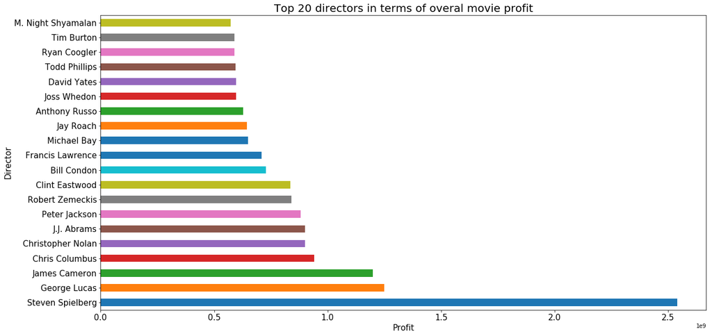

```python
ax = imdb.groupby('director_name')['profit'].sum().sort_values(ascending=False).head(20).plot(kind='barh', figsize=(20,10), legend=False)
ax.set_title("Top 20 directors in terms of overal movie profit", fontsize=20)
ax.set_xlabel("Profit", fontsize=15)
ax.set_ylabel("Director", fontsize=15)
ax.tick_params(labelsize=15)
```

### Does the director affect the IMDB score for a movie?

```python
name_avg_IMDB_score(imdb['director_name'], "director").sort_values('Avg IMDB Score', ascending=False).head(10)
```

| Name | Occurrences | Avg IMDB Score |
| --- | --- | --- |
| Gustavo Goulart | 1 | 9.600000 |
| Roberto Benigni | 1 | 8.600000 |
| Olivier Nakache | 1 | 8.500000 |
| Nitesh Tiwari | 1 | 8.500000 |
| Giuseppe Tornatore | 1 | 8.500000 |
| S.S. Rajamouli | 1 | 8.400000 |
| Christopher Nolan | 9 | 8.366667 |
| Lee Unkrich | 2 | 8.350000 |
| Damien Chazelle | 2 | 8.300000 |
| Michael Powell | 1 | 8.300000 |

```
Text(0.5,0,'Avg IMDB Score')
```

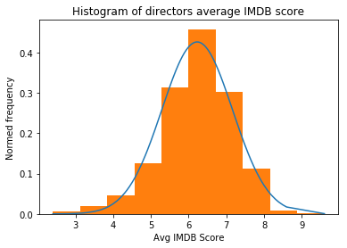

```python
df = name_avg_IMDB_score(imdb['director_name'], "director")
h = sorted(df['Avg IMDB Score'])
fit = norm.pdf(h, np.mean(h), np.std(h))
plt.plot(h, fit, '')
plt.hist(h, density=True)
plt.title("Histogram of directors average IMDB score")
plt.ylabel('Normed frequency')
plt.xlabel('Avg IMDB Score')
```

```python
df = name_avg_IMDB_score(imdb['director_name'], "director")
filt = (df['Occurrences'] >= 5) & (df['Avg IMDB Score'] >= 7) & (df['Avg IMDB Score'] <= 8)
df = df[filt].sort_values('Avg IMDB Score', ascending=False)
df.head(10)
```

| Name | Occurrences | Avg IMDB Score |
| --- | --- | --- |
| Alfred Hitchcock | 7 | 8.000000 |
| Stanley Kubrick | 6 | 7.983333 |
| James Cameron | 7 | 7.900000 |
| David Lean | 5 | 7.880000 |
| Peter Jackson | 9 | 7.844444 |
| Fred Zinnemann | 5 | 7.800000 |
| Milos Forman | 6 | 7.766667 |
| David Fincher | 10 | 7.750000 |
| Billy Wilder | 6 | 7.750000 |
| Martin Scorsese | 17 | 7.694118 |

Director Gustavo Goulart has the highest average IMDB Score. However, this is a bit misleading as he only has one movie in the dataset. A histogram of all the data shows that the average IMDB scores directors is mediocre with the highest scores being between 6 and 7.

### Does the cast affect the IMDB score?

```python
# We need to make a DataFrame that includes all three columns of names and their respective imdb_score
df = imdb[['actor_1_name', 'imdb_score']].rename(columns={"actor_1_name": "Name"})
df2 = imdb[['actor_2_name', 'imdb_score']].rename(columns={"actor_2_name": "Name"})
df3 = imdb[['actor_3_name', 'imdb_score']].rename(columns={"actor_3_name": "Name"})

# re-index each new dataframe so we can append into one by index.
len1 = len(df['Name'])+1
df2.index = df2.index +len1
len2 = len(df2['Name'])+1
df3.index = df3.index +len1+len2

dfs = [df, df2, df3]

# Merge all data into dataframe
merged = pd.concat(dfs)
```

```python
df = name_avg_IMDB_score(merged['Name'], "cast")
```

### Top actors in relation to IMDB scores

```python
df.sort_values('Avg IMDB Score', ascending=False).head(10)
```

| Name | Occurrences | Avg IMDB Score |
| --- | --- | --- |
| Gustavo Goulart | 1 | 9.6 |
| Jonathan Sagall | 1 | 8.9 |
| Laura Lovelace | 1 | 8.9 |
| Noel Appleby | 1 | 8.9 |
| Alan Howard | 1 | 8.8 |
| John Bach | 2 | 8.8 |
| Meat Loaf | 1 | 8.8 |
| Richmond Arquette | 1 | 8.8 |
| Harold G. Herthum | 1 | 8.8 |
| Alonzo Brown | 1 | 8.7 |

### Top actors in relation to overall profit

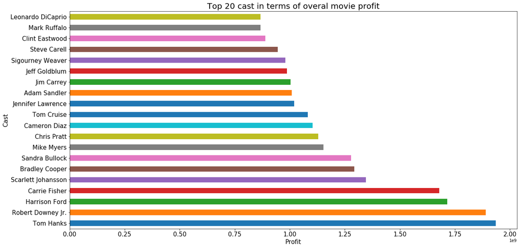

```python
# We need to make a DataFrame that includes all three columns of names and their respective imdb_score
df = imdb[['actor_1_name', 'imdb_score', 'profit']].rename(columns={"actor_1_name": "Name"})
df2 = imdb[['actor_2_name', 'imdb_score', 'profit']].rename(columns={"actor_2_name": "Name"})
df3 = imdb[['actor_3_name', 'imdb_score', 'profit']].rename(columns={"actor_3_name": "Name"})

df = df.dropna()
df2 = df2.dropna()
df3 = df3.dropna()
# re-index each new dataframe so we can append into one by index.
len1 = len(df['Name'])+1
df2.index = df2.index +len1
len2 = len(df2['Name'])+1
df3.index = df3.index +len1+len2

dfs = [df, df2, df3]

# Merge all data into dataframe
merged = pd.concat(dfs)
merged = merged.reset_index()
ax = merged.groupby('Name')['profit'].sum().sort_values(ascending=False).head(20).plot(kind='barh', figsize=(20,10), legend=False)

ax.set_title("Top 20 cast in terms of overal movie profit", fontsize=20)
ax.set_xlabel("Profit", fontsize=15)
ax.set_ylabel("Cast", fontsize=15)
ax.tick_params(labelsize=15)
```

```
Text(0.5,0,'Avg IMDB Score')
```

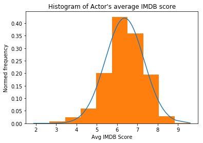

```python
h = sorted(df['Avg IMDB Score'])
fit = norm.pdf(h, np.mean(h), np.std(h))
plt.plot(h, fit, '')
plt.hist(h, density=True)
plt.title("Histogram of Actor's average IMDB score")
plt.ylabel('Normed frequency')
plt.xlabel('Avg IMDB Score')
```

The Actors show much of the same data as with the director. There is a slight difference in that the averages are slightly higher.

## How does the genre relate to a movie's success?

```python
# This function counts the number of genres filtered by a specific imdb score that is passed into the function=
# n is a single numbe =r to look for
# c is the column name we want to search in.
# r1 is the first range value
# r2 is the second range value
def genre_filter(c, n=0, r1=0, r2=0, all_genres=0):
    # List of genres we will be searching for in dataset
    genre_list = ['Drama', 'Comedy', 'Thriller', 'Action' ,'Romance' ,'Adventure','Crime','Family','Fantasy','Sci-Fi','Mystery','Horror','Animation','Biography','Sport','Music','History','War','Musical','Western','Film-Noir']

    genre = []
    score = []

    # Iterate through list of genres and search for the occurance of that genre
    # Additionally filter rows that are below the passed in score
    for i in range(len(genre_list)):
        # if a range is specified, filter by the specified range.
        if r1:
            filt2 = (imdb['genres'].str.contains(genre_list[i], regex=False)) & (imdb[c] >= r1) & (imdb[c] <= r2)
        elif all_genres:
            filt2 = (imdb['genres'].str.contains(genre_list[i], regex=False))
        else:
            filt2 = (imdb['genres'].str.contains(genre_list[i], regex=False)) & (imdb[c] >= n)
        df2 = imdb[filt2].sort_values('imdb_score', ascending=False)
        # get the count of the number of occurances of genres
        count = df2['genres'].count()
        #if count is 0, make it a NaN so we can drop it later
        if count == 0:
            genre = genre + [genre_list[i]]
            score = score + [np.NaN]
        else:
        # else add the count to the appropriate place in the new dataframe
            genre = genre + [genre_list[i]]
            score = score + [count]
    d = zip(genre, score)
    df = pd.DataFrame(d, columns=['Genre', 'Count']).set_index('Genre')
    # drop any null values
    df = df.dropna()
    # sort values in the data frame
    df = df.sort_values('Count', ascending=True)
    # return the data frame
    return df
```

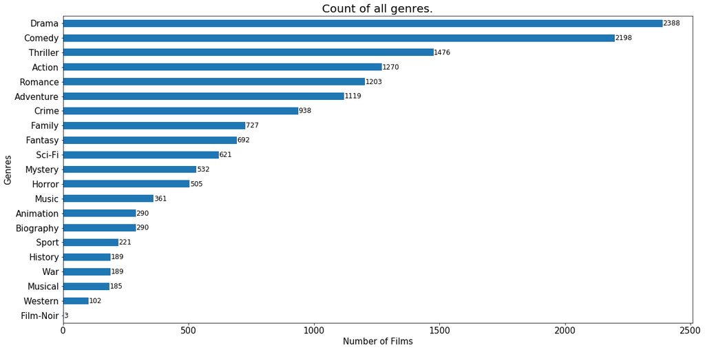

```python
ax = genre_filter("profit", all_genres='y').plot(kind='barh', figsize=(20,10), legend=False)
ax.set_title("Count of all genres.", fontsize=20)
ax.set_xlabel("Number of Films", fontsize=15)
ax.set_ylabel("Genres", fontsize=15)
ax.tick_params(labelsize=15)

for p in ax.patches:
    ax.annotate(str(p.get_width()), (p.get_width()+1, p.get_y()+.1), fontsize=12)
```

### Which genres have an IMDB score equal to or higher than 9?

[figure not shown]

```python
ax = genre_filter("imdb_score", n=9).plot(kind='barh', figsize=(20,10), legend=False)
ax.set_title("Genres with and IMDB score of 9 or higher", fontsize=15)
ax.set_xlabel("Number of Films", fontsize=15)
ax.set_ylabel("Genres", fontsize=15)
ax.tick_params(labelsize=15)

for p in ax.patches:
    ax.annotate(str(p.get_width()), (p.get_width()+.05, p.get_y()+.18), fontsize=15)
```

### Which Genres have an IMDB score equal or higher than 8?

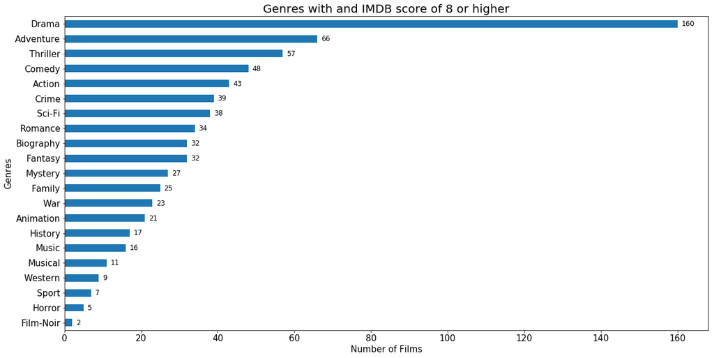

```python
ax = genre_filter("imdb_score", n=8).plot(kind='barh', figsize=(20,10), legend=False)
ax.set_title("Genres with and IMDB score of 8 or higher", fontsize=20)
ax.set_xlabel("Number of Films", fontsize=15)
ax.set_ylabel("Genres", fontsize=15)
ax.tick_params(labelsize=15)

for p in ax.patches:
    ax.annotate(str(p.get_width()), (p.get_width()+1, p.get_y()+.1), fontsize=12)
```

### Which Genres have an IMDB score equal or higher than 7?

[figure not shown]

```python
ax = genre_filter("imdb_score", n=7).plot(kind='barh', figsize=(20,10), legend=False)
ax.set_title("Genres with and IMDB score of 7 or higher", fontsize=20)
ax.set_xlabel("Number of Films", fontsize=15)
ax.set_ylabel("Genres", fontsize=15)
ax.tick_params(labelsize=15)

for p in ax.patches:
    ax.annotate(str(p.get_width()), (p.get_width()+1, p.get_y()+.1), fontsize=12)
```

## Which Genres produce the most profits?

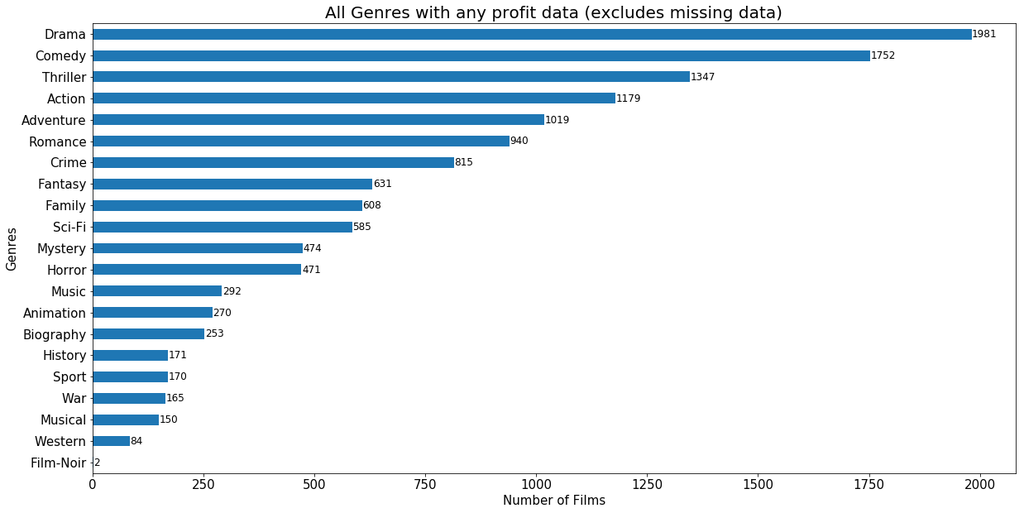

```python
ax = genre_filter("profit", r1=imdb['profit'].min(), r2=imdb['profit'].max()).plot(kind='barh', figsize=(20,10), legend=False)
ax.set_title("All Genres with any profit data (excludes missing data)", fontsize=20)
ax.set_xlabel("Number of Films", fontsize=15)
ax.set_ylabel("Genres", fontsize=15)
ax.tick_params(labelsize=15)

for p in ax.patches:
    ax.annotate(str(p.get_width()), (p.get_width()+1, p.get_y()+.1), fontsize=12)
```

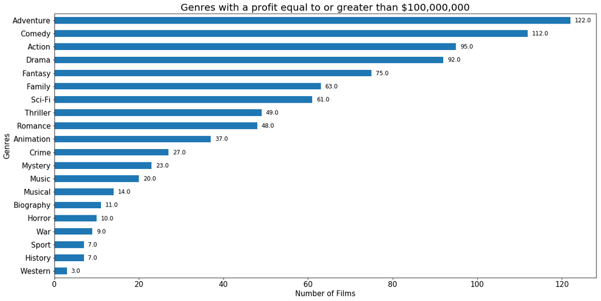

```python
ax = genre_filter("profit", n=100000000).plot(kind='barh', figsize=(20,10), legend=False)
ax.set_title("Genres with a profit equal to or greater than $100,000,000", fontsize=20)
ax.set_xlabel("Number of Films", fontsize=15)
ax.set_ylabel("Genres", fontsize=15)
ax.tick_params(labelsize=15)

for p in ax.patches:
    ax.annotate(str(p.get_width()), (p.get_width()+1, p.get_y()+.1), fontsize=12)
```

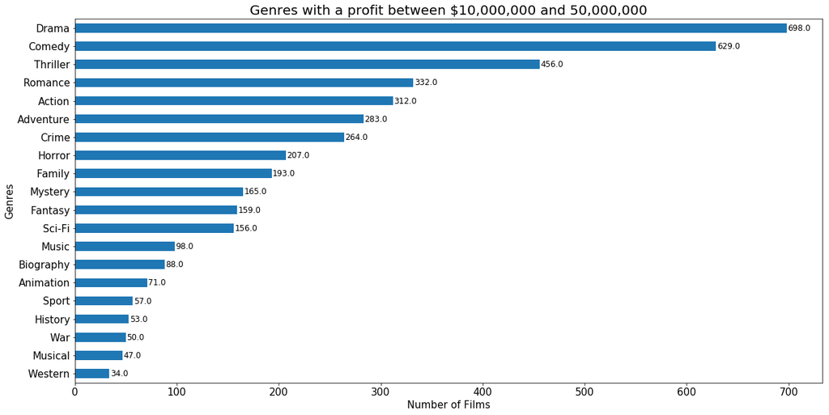

```python
ax = genre_filter("profit", r1=10000000, r2=50000000).plot(kind='barh', figsize=(20,10), legend=False)
ax.set_title("Genres with a profit between $10,000,000 and 50,000,000", fontsize=20)
ax.set_xlabel("Number of Films", fontsize=15)
ax.set_ylabel("Genres", fontsize=15)
ax.tick_params(labelsize=15)

for p in ax.patches:
    ax.annotate(str(p.get_width()), (p.get_width()+1, p.get_y()+.1), fontsize=12)
```

#### The top 5 genres in terms of frequency are:

```
1. Drama
2. Comedy
3. Thriller
4. Action
5. Romance
```

However, when we look at genres in terms of IMDB score or profits, we can see a little variation in the top 5 genres. See below:

| Top 5 Genres based on the IMDB score and Profit |  |  |  |  |
| --- | --- | --- | --- | --- |
| IMDB Score |  |  | Profit |  |
| Greater than or equal to 9 | Greater than or equal to 8 | Greater than or equal to 7 | Greater than or equal to 100,000,000 | Between 10,000,000 and 50,000,000 |
| Drama | Drama | Drama | Adventure | Drama |
| Crime | Adventure | Comedy | Comedy | Comedy |
| Musical | Thriller | Thriller | Action | Thriller |
| Music | Comedy | Adventure | Drama | Romance |
| Action | Action | Romance | Fantasy | Action |

For the most part, the most popular genre is Drama. However, when we look at movies that have profits greater than 100 million dollars, the top genre is Adventure, followed by Comedy, Action, Drama, Fantasy. It interesting to see that Drama, which is the top genre across the board, is fourth for movies that the profits greater than 100 million dollars.

## Is there a relationship for movie content rating and the IMDB Score?

[figure not shown]

```python
ax=imdb.groupby('content_rating')['imdb_score'].mean().sort_values(ascending=False).plot(kind='barh', figsize=(20,10), legend=False)
ax.set_title("Average IMDB score for a Movie in relation to the content rating", fontsize=20)
ax.set_xlabel("Average IMDB Score", fontsize=15)
ax.set_ylabel("Rating", fontsize=15)
plt.xlim((5, 8))
ax.tick_params(labelsize=15)
```

## Is there a relationship for movie content rating and profit?

### First, how many movies in the main content rating categories?

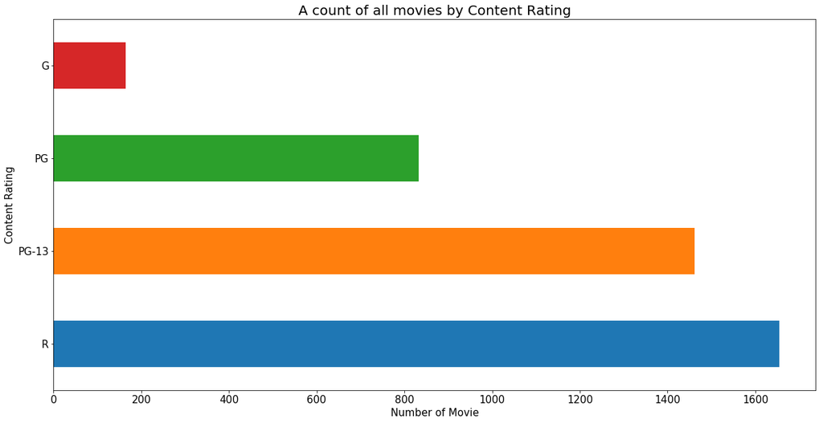

```python
filt = (imdb['content_rating'] == "G")  | (imdb['content_rating'] == "PG") | (imdb['content_rating'] == "PG-13") |(imdb['content_rating'] == "R")

ax =imdb[filt].groupby('content_rating')['profit'].count().sort_values(ascending=False).plot(kind='barh', figsize=(20,10), legend=False)

ax.set_title("A count of all movies by Content Rating", fontsize=20)
ax.set_xlabel("Number of Movie", fontsize=15)
ax.set_ylabel("Content Rating", fontsize=15)
ax.tick_params(labelsize=15)
```

### Which content ratings have generated the most profits?

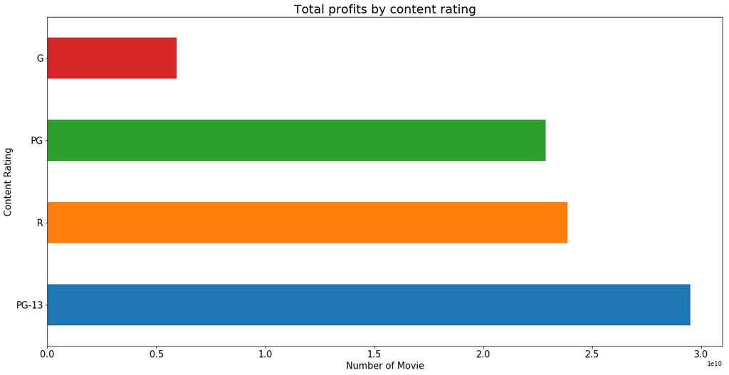

```python
filt = (imdb['content_rating'] == "G")  | (imdb['content_rating'] == "PG") | (imdb['content_rating'] == "PG-13") |(imdb['content_rating'] == "R")

ax = imdb[filt].groupby('content_rating')['profit'].sum().sort_values(ascending=False).plot(kind='barh', figsize=(20,10), legend=False)

ax.set_title("Total profits by content rating", fontsize=20)
ax.set_xlabel("Number of Movie", fontsize=15)
ax.set_ylabel("Content Rating", fontsize=15)
ax.tick_params(labelsize=15)
```

### Which content rating, on average, makes the most profits?

```
Text(0,0.5,'Content Rating')
```

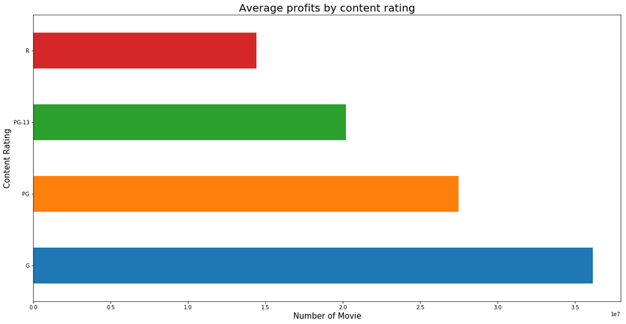

```python
filt = (imdb['content_rating'] == "G")  | (imdb['content_rating'] == "PG") | (imdb['content_rating'] == "PG-13") |(imdb['content_rating'] == "R")

ax = imdb[filt].groupby('content_rating')['profit'].mean().sort_values(ascending=False).plot(kind='barh', figsize=(20,10), legend=False)

ax.set_title("Average profits by content rating", fontsize=20)
ax.set_xlabel("Number of Movie", fontsize=15)
ax.set_ylabel("Content Rating", fontsize=15)
```

The content rating doesn't seem to have much affect on the IMDB score. However, the content rating seems to have a significant affect on profits.

R rated movies are produced more frequently, however, they have not generate the most profit. PG-13 movies have mad the most profits. What is even more interesting is when we look at the average profits, G rated movies have the highest average profit earned.

## How does the number of Oscars won\nominated affect the IMDB score.

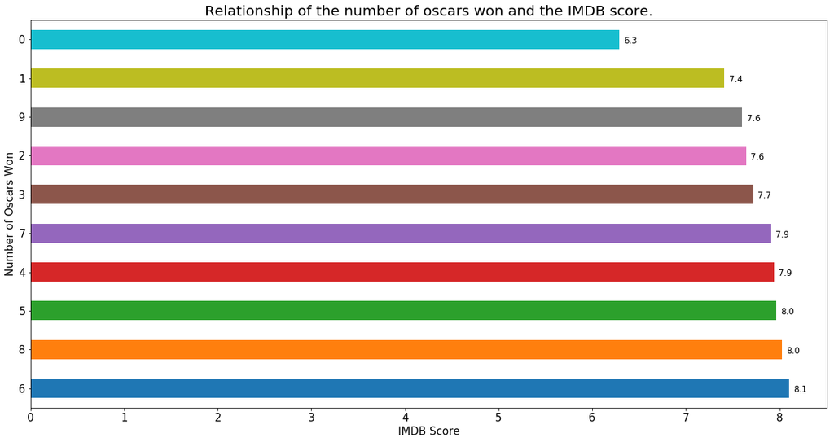

```python
filt = (imdb['oscar_wins'] >= 0)

ax = imdb[filt].groupby('oscar_wins')['imdb_score'].mean().sort_values(ascending=False).head(30).plot(kind='barh', figsize=(20,10), legend=False)

ax.set_title("Relationship of the number of oscars won and the IMDB score.", fontsize=20)
ax.set_xlabel("IMDB Score", fontsize=15)
ax.set_ylabel("Number of Oscars Won", fontsize=15)
ax.tick_params(labelsize=15)

for p in ax.patches:
    ax.annotate(str(round(p.get_width(), 1)), (p.get_width()+.05, p.get_y()+.15), fontsize=12)
```

[figure not shown]

```python
filt = (imdb['oscar_noms'] >= 0)
ax = imdb[filt].groupby('oscar_noms')['imdb_score'].mean().sort_values(ascending=False).head(30).plot(kind='barh', figsize=(20,10), legend=False)

ax.set_title("Number of Oscar Nominations vs the IMDB score.", fontsize=20)
ax.set_xlabel("IMDB Score", fontsize=15)
ax.set_ylabel("Number of Oscars Won", fontsize=15)
ax.tick_params(labelsize=15)

for p in ax.patches:
    ax.annotate(str(round(p.get_width(), 1)), (p.get_width()+.05, p.get_y()+.15), fontsize=12)
```

Please note: This data may be a bit misleading due to the method of collection. The data that was collected only scraped the available information on the main movie web-page. Unfortunately, if a movie won an Oscar, IMDB doesn't display the number of Oscars it was nominated for on the main movie page.

For example, the movie Avatar had 3 Oscar wins and 6 Nominations. However, since IMDB only displayed the wins, the data on the nominations was not collected.

## Correlation Analysis

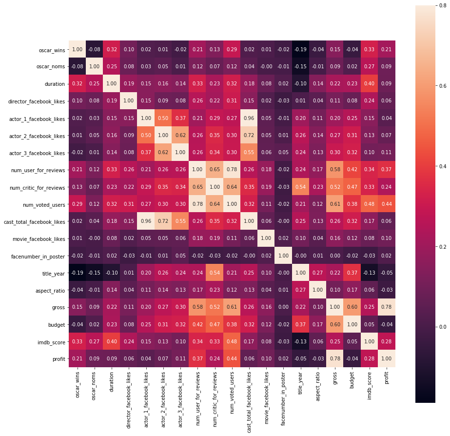

```python
plt.figure(figsize=(15,15))
sns.heatmap(imdb.corr(), vmax=.8, square=True, annot=True, fmt=".2f")
```

This may be showing that people value the opinion of others.

```python
stopwords = ["character", "reference", "based", "on", "the", "of", "in", "to", "female", "male", "man", "woman", "film", "girl", "boy", "by", "title", "protagonist", "york", "city"]

filt = (imdb['profit'] >= 100000000)

d = imdb[filt]
text = ""
for i in d['plot_keywords']:
    text = text +i
text = text.replace("'", "")
text = text.replace("]", ",")
text = text.replace("[", "")

wordcloud = WordCloud(stopwords=stopwords, background_color="white", height=500, width=2000).generate(text)

wordcloud.to_file("data/greaterthan.png")

#*************************************************************************************************************
filt = (imdb['profit'] <= 100000000)

d = imdb[filt]
text = ""
for i in d['plot_keywords']:
    text = text +i
text = text.replace("'", "")
text = text.replace("]", ",")
text = text.replace("[", "")

wc = WordCloud(stopwords=stopwords, background_color="white", height=500, width=2000).generate(text)
wc.to_file("data/lessthan.png")
```

```
<wordcloud.wordcloud.WordCloud at 0x1a08e10250>
```

# Plot keywords for Movie's with profits greater than 100,000,000

[figure not shown]

# Plot keywords for Movie's with profits less than 100,000,000

[figure not shown]

# Regression Analysis

```python
# imports
#regression packages
import sklearn.linear_model as lm
from sklearn.metrics import mean_squared_error
from sklearn.metrics import explained_variance_score

#lasso regression
from sklearn import linear_model

#f_regression (feature selection)
from sklearn.feature_selection import f_regression
from sklearn.feature_selection import SelectKBest

# recursive feature selection (feature selection)
from sklearn.feature_selection import RFE

import statsmodels.api as sm
from statsmodels.formula.api import ols
```

## Extract Transform Loading

Since we have not accomplished ETL up to this stage, it is necessary to clean the data for modeling purposes. The data, as it is, is already fairly clean due to the additional steps taken to re-scrape the data at the beginning of the Mid-Term project. However, there is still 767 rows missing data in the budget column. I decided that I didn't want to lost that data by dropping rows, so I filled all null data in the bugdet, profit, and gross columns with 0 and dropped all other null rows.

Additionally, we need to transform some of the categorical values to numerical values for those columns to be considered as a predictor. However, due to the number of variation in some of the columns, we will not need the following columns and will be dropping those as well.

- movie_title
- director_name
- actor_1_name
- actor_2_name
- actor_3_name
- plot_keywords
- language
- country
- movie_imdb_link
- genres

```python
pd.set_option('display.max_colwidth', -1)
pd.set_option('display.max_columns', None)
pd.set_option('display.max_rows', None)

# We need to convert certain text to int for it to be considered as a predictor.
# Titles and Director\Actor names will be dropped as well as plot_keywords.

data = imdb

# First fill budget, gross, and profit with 0
# this is the bulk of the null data and i did not want to lose it.
data = data.fillna({'budget': 0, 'gross': 0, 'profit': 0})

# Second, drop the rest of the null data
data = data.dropna()


# Drop Movie Title, Director Name, Actor 1-3 name, Plot Keywords, Genres, Langauge, Country and Movie Link
data = data.drop(['movie_title', 'director_name', 'actor_1_name', 'actor_2_name', 'actor_3_name', 'plot_keywords', 'language', 'country', 'movie_imdb_link'], axis=1)

# map categorical value to numerical values
data['color'] = data['color'].map({'Black and White': 0, 'Color': 1})

# We only care about content ratings of G, PG, PG-13, R. Dropping the ones we don't care about will only drop 109 entries.
to_keep = ['PG-13', 'PG', 'G', 'R']
data = data.loc[data.content_rating.isin(to_keep)]

# Map Content Rating categorical values to numerical values
data['content_rating'] = data['content_rating'].map({'G': 0, 'PG': 1, 'PG-13': 2, 'R': 3})
```

```python
data.head()
```

|  | oscar_wins | oscar_noms | duration | director_facebook_likes | actor_1_facebook_likes | actor_2_facebook_likes | actor_3_facebook_likes | num_user_for_reviews | num_critic_for_reviews | num_voted_users | cast_total_facebook_likes | movie_facebook_likes | facenumber_in_poster | color | genres | title_year | content_rating | aspect_ratio | gross | budget | imdb_score | profit |
| --- | --- | --- | --- | --- | --- | --- | --- | --- | --- | --- | --- | --- | --- | --- | --- | --- | --- | --- | --- | --- | --- | --- |
| 0 | 3 | 0 | 178 | 5400 | 5700 | 3100.0 | 2900.0 | 3184.0 | 723 | 1004105 | 11700 | 26000 | 0 | 1 | Action\|Adventure\|Fantasy\|Sci-Fi | 2009 | 2 | 1.78 | 760507625.0 | 237000000.0 | 7.8 | 523507625.0 |
| 1 | 0 | 4 | 152 | 1300 | 2300 | 1000.0 | 0.0 | 5629.0 | 650 | 418687 | 3300 | 3300 | 5 | 1 | Action\|Adventure\|Fantasy\|Sci-Fi | 2017 | 2 | 2.39 | 620181382.0 | 0.0 | 7.2 | 0.0 |
| 2 | 1 | 0 | 194 | 5400 | 21000 | 1500.0 | 563.0 | 2586.0 | 316 | 912242 | 23063 | 810 | 0 | 1 | Drama\|Romance | 1997 | 2 | 2.39 | 659325379.0 | 200000000.0 | 7.8 | 459325379.0 |
| 3 | 0 | 1 | 173 | 4400 | 14000 | 11000.0 | 4900.0 | 1758.0 | 722 | 1127434 | 29900 | 804 | 3 | 1 | Action\|Adventure\|Sci-Fi | 2012 | 2 | 1.78 | 623357910.0 | 220000000.0 | 8.1 | 403357910.0 |
| 4 | 0 | 5 | 136 | 13000 | 9800 | 4600.0 | 2000.0 | 4387.0 | 860 | 755440 | 16400 | 207 | 3 | 1 | Action\|Adventure\|Fantasy\|Sci-Fi | 2015 | 2 | 2.39 | 936662225.0 | 245000000.0 | 8.0 | 691662225.0 |

```python
# Convert the string to list
# https://stackoverflow.com/questions/50278300/convert-a-columns-of-string-to-list-in-pandas
data['genres'] = data['genres'].str.split(',')

# One hot encode columns with a list of strings as values
# https://stackoverflow.com/questions/47786822/how-do-you-one-hot-encode-columns-with-a-list-of-strings-as-values
df1 = data['genres'].str.join('|').str.get_dummies()

# Join dummies to orignal data
data = data.join(df1)

# drop genres column
data = data.drop('genres', axis=1)

# Remove dash from Sci-Fi for later
data = data.rename({'Sci-Fi': 'SciFi'}, axis=1)
data.head()
```

|  | oscar_wins | oscar_noms | duration | director_facebook_likes | actor_1_facebook_likes | actor_2_facebook_likes | actor_3_facebook_likes | num_user_for_reviews | num_critic_for_reviews | num_voted_users | cast_total_facebook_likes | movie_facebook_likes | facenumber_in_poster | color | title_year | content_rating | aspect_ratio | gross | budget | imdb_score | profit | Action | Adventure | Animation | Biography | Comedy | Crime | Drama | Family | … |
| --- | --- | --- | --- | --- | --- | --- | --- | --- | --- | --- | --- | --- | --- | --- | --- | --- | --- | --- | --- | --- | --- | --- | --- | --- | --- | --- | --- | --- | --- | --- |
| 0 | 3 | 0 | 178 | 5400 | 5700 | 3100.0 | 2900.0 | 3184.0 | 723 | 1004105 | 11700 | 26000 | 0 | 1 | 2009 | 2 | 1.78 | 760507625.0 | 237000000.0 | 7.8 | 523507625.0 | 1 | 1 | 0 | 0 | 0 | 0 | 0 | 0 | … |
| 1 | 0 | 4 | 152 | 1300 | 2300 | 1000.0 | 0.0 | 5629.0 | 650 | 418687 | 3300 | 3300 | 5 | 1 | 2017 | 2 | 2.39 | 620181382.0 | 0.0 | 7.2 | 0.0 | 1 | 1 | 0 | 0 | 0 | 0 | 0 | 0 | … |
| 2 | 1 | 0 | 194 | 5400 | 21000 | 1500.0 | 563.0 | 2586.0 | 316 | 912242 | 23063 | 810 | 0 | 1 | 1997 | 2 | 2.39 | 659325379.0 | 200000000.0 | 7.8 | 459325379.0 | 0 | 0 | 0 | 0 | 0 | 0 | 1 | 0 | … |
| 3 | 0 | 1 | 173 | 4400 | 14000 | 11000.0 | 4900.0 | 1758.0 | 722 | 1127434 | 29900 | 804 | 3 | 1 | 2012 | 2 | 1.78 | 623357910.0 | 220000000.0 | 8.1 | 403357910.0 | 1 | 1 | 0 | 0 | 0 | 0 | 0 | 0 | … |
| 4 | 0 | 5 | 136 | 13000 | 9800 | 4600.0 | 2000.0 | 4387.0 | 860 | 755440 | 16400 | 207 | 3 | 1 | 2015 | 2 | 2.39 | 936662225.0 | 245000000.0 | 8.0 | 691662225.0 | 1 | 1 | 0 | 0 | 0 | 0 | 0 | 0 | … |

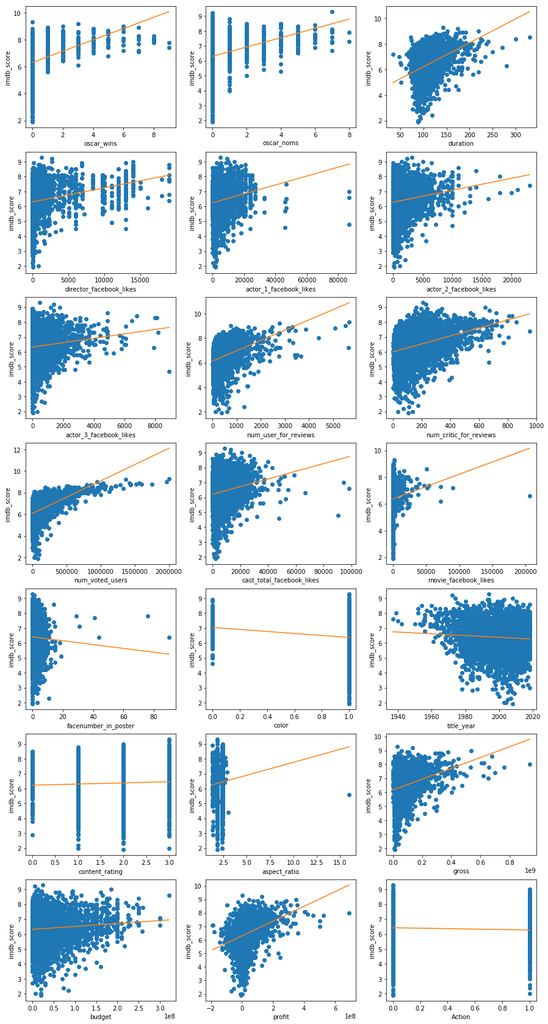

```python
# View all scatter plot of all predictors and a trend line

pd.set_option('display.max_rows', 500)

plt.figure(figsize=(15, 30))
score = data['imdb_score']
varibles = data.drop(['imdb_score'],  axis=1)

for i, col in enumerate(varibles.columns):
    if i < 21:
        plt.subplot(7, 3, i+1)
        x = data[col]
        y = data.imdb_score

        plt.plot(x, y, 'o')
        plt.plot(np.unique(x), np.poly1d(np.polyfit(x, y, 1))(np.unique(x)))
        plt.xlabel(col)
        plt.ylabel('imdb_score')
```

## Correlation Analysis

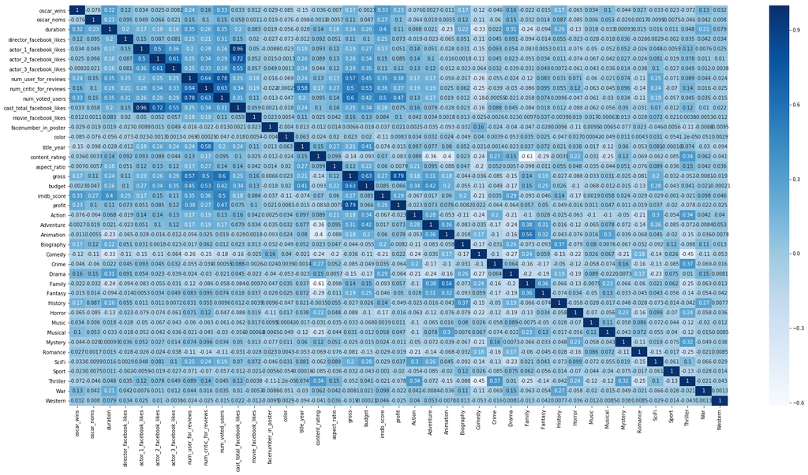

```python
plt.figure(figsize=(30,15))
sns.heatmap(data.corr(), annot=True, cmap='Blues')
```

# Which variables appear to influence a movie's IMDB score?

There are a few variables that seem to affect a movie's IMDB score:

- The number of Oscars a movie wins or in nominated for has a positive affect on a movies IMDB score
  - The same holds true for the following:
    - Duration
    - Director\Actor Facebook like
    - Number of users\critics for review and number of voted users.
    - The Movie's facbook likes
    - Gross Budget and Profit

## Building and Evaluating regression models

## Multiple Regression Model

```python
# build a multiple regression model below
y = data['imdb_score']
x = data.drop(['imdb_score'], axis=1)

model = lm.LinearRegression()
model.fit(x, y)
model_y = model1.predict(x)
```

```python
coef = ["%.3f" % i for i in model.coef_]
xcolumns = [ i for i in x.columns ]
zip(xcolumns, coef)
```

```
[('oscar_wins', '0.046'),
 ('oscar_noms', '0.100'),
 ('duration', '0.006'),
 ('director_facebook_likes', '0.000'),
 ('actor_1_facebook_likes', '0.000'),
 ('actor_2_facebook_likes', '0.000'),
 ('actor_3_facebook_likes', '-0.000'),
 ('num_user_for_reviews', '-0.000'),
 ('num_critic_for_reviews', '0.003'),
 ('num_voted_users', '0.000'),
 ('cast_total_facebook_likes', '-0.000'),
 ('movie_facebook_likes', '0.000'),
 ('facenumber_in_poster', '-0.005'),
 ('color', '-0.277'),
 ('title_year', '-0.022'),
 ('content_rating', '0.044'),
 ('aspect_ratio', '0.083'),
 ('gross', '0.000'),
 ('budget', '-0.000'),
 ('profit', '0.000'),
 ('Action', '-0.132'),
 ('Adventure', '-0.017'),
 ('Animation', '0.774'),
 ('Biography', '0.255'),
 ('Comedy', '-0.085'),
 ('Crime', '0.052'),
 ('Drama', '0.311'),
 ('Family', '-0.105'),
 ('Fantasy', '-0.064'),
 ('History', '0.087'),
 ('Horror', '-0.446'),
 ('Music', '-0.074'),
 ('Musical', '0.008'),
 ('Mystery', '0.091'),
 ('Romance', '-0.064'),
 ('SciFi', '-0.108'),
 ('Sport', '0.018'),
 ('Thriller', '-0.090'),
 ('War', '-0.032'),
 ('Western', '0.094')]
```

```python
print "mean square error: ", mean_squared_error(y, model_y)
print "variance or r-squared: ", explained_variance_score(y, model_y)
```

```
mean square error:  0.5992598740176938
variance or r-squared:  0.38787310723121693
```

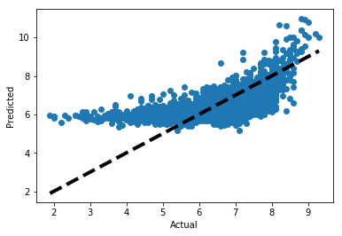

```python
plt.subplots()
plt.scatter(y, model_y)
plt.plot([y.min(), y.max()], [y.min(), y.max()], 'k--', lw=4)   #dotted line represents perfect prediction (actual = predicted)
plt.xlabel('Actual')
plt.ylabel('Predicted')
plt.show()
```

### Multiple Regression using Statsmodel

```python
pd.set_option('display.max_rows', 500)

reg_model = ols("imdb_score~oscar_wins+oscar_noms+duration+director_facebook_likes+actor_1_facebook_likes+actor_2_facebook_likes+actor_3_facebook_likes+num_user_for_reviews+num_critic_for_reviews+num_voted_users+cast_total_facebook_likes+movie_facebook_likes+facenumber_in_poster+color+title_year+content_rating+aspect_ratio+gross+budget+profit+Action+Adventure+Animation+Biography+Drama+Comedy+Crime+Family+Fantasy+History+Horror+Music+Musical+Mystery+Romance+SciFi+Sport+Thriller+War+Western", data)

run_reg_model = reg_model.fit()
print run_reg_model.summary()
```

```
                            OLS Regression Results
==============================================================================
Dep. Variable:             imdb_score   R-squared:                       0.513
Model:                            OLS   Adj. R-squared:                  0.509
Method:                 Least Squares   F-statistic:                     128.4
Date:                Wed, 05 Dec 2018   Prob (F-statistic):               0.00
Time:                        17:47:41   Log-Likelihood:                -5021.8
No. Observations:                4790   AIC:                         1.012e+04
Df Residuals:                    4750   BIC:                         1.038e+04
Df Model:                          39
Covariance Type:            nonrobust
=============================================================================================
                                coef    std err          t      P>|t|      [0.025      0.975]
---------------------------------------------------------------------------------------------
Intercept                    48.7190      2.397     20.323      0.000      44.019      53.419
oscar_wins                    0.0463      0.016      2.922      0.003       0.015       0.077
oscar_noms                    0.0996      0.013      7.738      0.000       0.074       0.125
duration                      0.0060      0.001      9.162      0.000       0.005       0.007
director_facebook_likes    1.027e-05   4.21e-06      2.441      0.015    2.02e-06    1.85e-05
actor_1_facebook_likes     5.016e-06   4.42e-06      1.134      0.257   -3.65e-06    1.37e-05
actor_2_facebook_likes      6.47e-06   8.82e-06      0.733      0.463   -1.08e-05    2.38e-05
actor_3_facebook_likes     -1.24e-05    1.4e-05     -0.886      0.376   -3.98e-05     1.5e-05
num_user_for_reviews         -0.0003   4.41e-05     -6.180      0.000      -0.000      -0.000
num_critic_for_reviews        0.0028      0.000     19.796      0.000       0.002       0.003
num_voted_users            2.097e-06   1.17e-07     17.944      0.000    1.87e-06    2.33e-06
cast_total_facebook_likes -9.028e-07   3.69e-06     -0.245      0.807   -8.14e-06    6.33e-06
movie_facebook_likes       8.282e-06   2.29e-06      3.616      0.000    3.79e-06    1.28e-05
facenumber_in_poster         -0.0047      0.004     -1.295      0.195      -0.012       0.002
color                        -0.2769      0.064     -4.324      0.000      -0.402      -0.151
title_year                   -0.0218      0.001    -18.010      0.000      -0.024      -0.019
content_rating                0.0442      0.016      2.703      0.007       0.012       0.076
aspect_ratio                  0.0827      0.032      2.587      0.010       0.020       0.145
gross                      1.794e-11   7.81e-10      0.023      0.982   -1.51e-09    1.55e-09
budget                    -3.141e-09   7.93e-10     -3.962      0.000    -4.7e-09   -1.59e-09
profit                     7.398e-10   7.87e-10      0.940      0.347   -8.03e-10    2.28e-09
Action                       -0.1318      0.030     -4.410      0.000      -0.190      -0.073
Adventure                    -0.0168      0.032     -0.532      0.595      -0.079       0.045
Animation                     0.7742      0.057     13.650      0.000       0.663       0.885
Biography                     0.2553      0.050      5.141      0.000       0.158       0.353
Drama                         0.3113      0.026     12.179      0.000       0.261       0.361
```

[output cut: 11 more lines]

```
Sport                         0.0180      0.051      0.352      0.725      -0.082       0.118
Thriller                     -0.0896      0.030     -2.999      0.003      -0.148      -0.031
War                          -0.0319      0.061     -0.525      0.600      -0.151       0.087
Western                       0.0943      0.076      1.236      0.216      -0.055       0.244
==============================================================================
Omnibus:                      746.179   Durbin-Watson:                   1.967
Prob(Omnibus):                  0.000   Jarque-Bera (JB):             1608.387
Skew:                          -0.920   Prob(JB):                         0.00
Kurtosis:                       5.161   Cond. No.                     8.61e+15
==============================================================================

Warnings:
[1] Standard Errors assume that the covariance matrix of the errors is correctly specified.
[2] The smallest eigenvalue is 7.41e-13. This might indicate that there are
strong multicollinearity problems or that the design matrix is singular.
```

Including all variables, does not yield good results in multiple regression modeling. We need to decide which are more important and test the regression models with more important factors.

According to the charts above, the following may be good predictors for a movie's IMDB score:

- Oscar Wins
- Oscar Nominations
- Duration
- Number of users who gave a review
- Number of users who voted for a movie
- Gross budget
- Profit

```python
reg_model = ols("imdb_score~oscar_wins+oscar_noms+duration+num_user_for_reviews+num_voted_users+gross+profit+num_critic_for_reviews+director_facebook_likes+Drama+Biography", data)
reg = reg_model.fit()
print reg.summary()
```

```
                            OLS Regression Results
==============================================================================
Dep. Variable:             imdb_score   R-squared:                       0.432
Model:                            OLS   Adj. R-squared:                  0.430
Method:                 Least Squares   F-statistic:                     330.0
Date:                Wed, 05 Dec 2018   Prob (F-statistic):               0.00
Time:                        17:42:20   Log-Likelihood:                -5392.3
No. Observations:                4790   AIC:                         1.081e+04
Df Residuals:                    4778   BIC:                         1.089e+04
Df Model:                          11
Covariance Type:            nonrobust
===========================================================================================
                              coef    std err          t      P>|t|      [0.025      0.975]
-------------------------------------------------------------------------------------------
Intercept                   5.1782      0.064     80.794      0.000       5.053       5.304
oscar_wins                  0.1398      0.016      8.673      0.000       0.108       0.171
oscar_noms                  0.1757      0.013     13.195      0.000       0.150       0.202
duration                    0.0062      0.001      9.720      0.000       0.005       0.007
num_user_for_reviews       -0.0003   4.47e-05     -7.757      0.000      -0.000      -0.000
num_voted_users          2.478e-06    1.2e-07     20.706      0.000    2.24e-06    2.71e-06
gross                   -2.496e-09   3.24e-10     -7.708      0.000   -3.13e-09   -1.86e-09
profit                   3.822e-09   3.68e-10     10.383      0.000     3.1e-09    4.54e-09
num_critic_for_reviews      0.0011      0.000      9.489      0.000       0.001       0.001
director_facebook_likes  2.152e-05   4.46e-06      4.824      0.000    1.28e-05    3.03e-05
Drama                       0.3728      0.024     15.318      0.000       0.325       0.421
Biography                   0.2749      0.049      5.579      0.000       0.178       0.372
==============================================================================
Omnibus:                      623.001   Durbin-Watson:                   1.975
Prob(Omnibus):                  0.000   Jarque-Bera (JB):             1200.655
Skew:                          -0.824   Prob(JB):                    1.91e-261
Kurtosis:                       4.816   Cond. No.                     5.97e+08
==============================================================================

Warnings:
[1] Standard Errors assume that the covariance matrix of the errors is correctly specified.
[2] The condition number is large, 5.97e+08. This might indicate that there are
strong multicollinearity or other numerical problems.
```

More Variables actually yields better results. When we limit the variable, the R-Squared is reduced, meaning more error is introduced.

## Regression model based on regularization

```python
# Lasso Regression (regularization)
from sklearn import linear_model
y = data['imdb_score']
x = data.drop(['imdb_score'], axis=1)

model1 = lm.Lasso(alpha=1)
model1.fit(x, y)
model1_y = model1.predict(x)

print "mean square error: ", mean_squared_error(y, model1_y)
print "variance or r-squared: ", explained_variance_score(y, model1_y)
```

```
mean square error:  0.5992598740176938
variance or r-squared:  0.38787310723121693
```

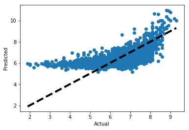

```python
plt.subplots()
plt.scatter(y, model1_y)
plt.plot([y.min(), y.max()], [y.min(), y.max()], 'k--', lw=4)   #dotted line represents perfect prediction (actual = predicted)
plt.xlabel('Actual')
plt.ylabel('Predicted')
plt.show()
```

## Regression model based on feature selection

```python
X_new = SelectKBest(f_regression, k=11).fit_transform(x, y)

model2 = lm.LinearRegression()
model2.fit(X_new, y)
model2_y = model2.predict(X_new)

print "mean square error: ", mean_squared_error(y, model2_y)
print "variance or r-squared: ", explained_variance_score(y, model2_y)
```

```
mean square error:  0.5598395531059251
variance or r-squared:  0.4281398422453433
```

```python
pd.set_option('display.max_columns', 500)
print X_new[0]
```

```
[3.00000000e+00 0.00000000e+00 1.78000000e+02 5.40000000e+03
 3.18400000e+03 7.23000000e+02 1.00410500e+06 7.60507625e+08
 5.23507625e+08 0.00000000e+00 0.00000000e+00]
```

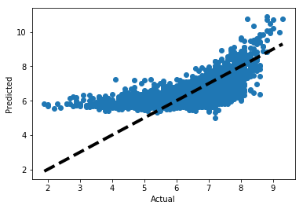

```python
plt.subplots()
plt.scatter(y, model2_y)
plt.plot([y.min(), y.max()], [y.min(), y.max()], 'k--', lw=4)   #dotted line represents perfect prediction (actual = predicted)
plt.xlabel('Actual')
plt.ylabel('Predicted')
plt.show()
```

## Normalization

```python
from sklearn.preprocessing import Normalizer

y = data['imdb_score']
X = data.drop(['imdb_score'], axis=1)

scaler = Normalizer().fit(X)
normalizedX = scaler.transform(X)
```

```python
model3 = lm.LinearRegression()
model3.fit(normalizedX, y)
model3_y = model3.predict(normalizedX)
```

```python
print "mean square error: ", mean_squared_error(y, model3_y)
print "variance or r-squared: ", explained_variance_score(y, model3_y)
```

```
mean square error:  0.8381337949090643
variance or r-squared:  0.14387020081533797
```

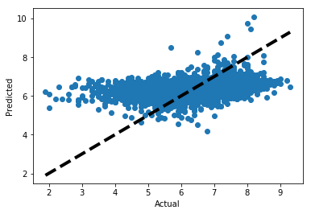

```python
plt.subplots()
plt.scatter(y, model3_y)
plt.plot([y.min(), y.max()], [y.min(), y.max()], 'k--', lw=4)   #dotted line represents perfect prediction (actual = predicted)
plt.xlabel('Actual')
plt.ylabel('Predicted')
plt.show()
```

- Oscars Wins
- Duration
- num_users_for_review
- num_critics_for_reviews
- num_voted_users
- profit

However, I observed that we have more error when we used a less amount of predictors.

# Classification Analysis

```python
#import decisiontreeclassifier
from sklearn import tree
from sklearn.tree import DecisionTreeClassifier, export_graphviz
from IPython.display import SVG
from IPython.display import display
#import logisticregression classifier
from sklearn.linear_model import LogisticRegression
import statsmodels.api as sm
#import knn classifier
from sklearn.neighbors import KNeighborsClassifier

#for validating your classification model
from sklearn.metrics import classification_report, f1_score, accuracy_score, confusion_matrix
from sklearn.model_selection import StratifiedKFold, cross_val_score, train_test_split, GridSearchCV
from sklearn import metrics
from sklearn.metrics import roc_curve, auc

# feature selection
from sklearn.feature_selection import RFE
from sklearn.ensemble import ExtraTreesClassifier
from sklearn.feature_selection import SelectKBest
from sklearn.feature_selection import chi2

#pip install scikit-plot (optional)
import scikitplot as skplt
```

## Data Cleaning for classification

```python
# There are a nunber of floats that the classifier cannot handle. Most of these can be convert to int. However, imdb_score andf aspect_ratio cannot be converted to int. Therefor, imdb_score will be binned into 4 categories and aspect_ratio will be dropped. According to the correlation above, there is almost no correlation between the aspect ratio and the imdb_score.

data.actor_2_facebook_likes = data.actor_2_facebook_likes.astype(int)
data.actor_3_facebook_likes = data.actor_3_facebook_likes.astype(int)
data.num_user_for_reviews = data.num_user_for_reviews.astype(int)
data.gross = data.gross.astype(int)
data.budget = data.budget.astype(int)
data.profit = data.profit.astype(int)

# Create bins containing a range of imdb scores
bins = [0, 4, 6, 8, 10]
names = ['0-4', '4-6', '6-8', '8-10']

# group score into bins for classification
data['imdb_score_bin'] = pd.cut(data.imdb_score, bins, labels=names)
```

### Decision Tree Classifier

```python
y = data['imdb_score_bin']
x = data.drop(['imdb_score_bin', 'aspect_ratio', 'imdb_score'], axis=1)

# split validation
x_train, x_test, y_train, y_test = train_test_split(x, y, test_size=0.3, random_state=0)

dt = DecisionTreeClassifier()

dt.fit(x_train, y_train)
```

```
DecisionTreeClassifier(class_weight=None, criterion='gini', max_depth=None,
            max_features=None, max_leaf_nodes=None,
            min_impurity_decrease=0.0, min_impurity_split=None,
            min_samples_leaf=1, min_samples_split=2,
            min_weight_fraction_leaf=0.0, presort=False, random_state=None,
            splitter='best')
```

```python
#Model evaluation
# http://scikit-learn.org/stable/modules/model_evaluation.html
print metrics.accuracy_score(y_test, dt.predict(x_test))
print "--------------------------------------------------------"
print metrics.confusion_matrix(y_test, dt.predict(x_test))
print "--------------------------------------------------------"
print metrics.classification_report(y_test, dt.predict(x_test))
print "--------------------------------------------------------"
```

```
0.6993736951983298
--------------------------------------------------------
[[  1  21   5   0]
 [ 10 291 173   0]
 [  8 178 693  19]
 [  0   1  17  20]]
--------------------------------------------------------
             precision    recall  f1-score   support

        0-4       0.05      0.04      0.04        27
        4-6       0.59      0.61      0.60       474
        6-8       0.78      0.77      0.78       898
       8-10       0.51      0.53      0.52        38

avg / total       0.70      0.70      0.70      1437

--------------------------------------------------------
```

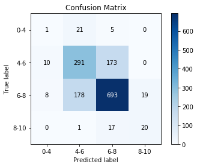

```python
# optional
#pip install scikit-plot
import scikitplot as skplt

skplt.metrics.plot_confusion_matrix(y_true=np.array(y_test), y_pred=dt.predict(x_test))
plt.show()
```

### K-Nearest Neighbor Model

```python
y = data['imdb_score_bin']
x = data.drop(['imdb_score_bin', 'aspect_ratio', 'imdb_score'], axis=1)

# split validation
x_train, x_test, y_train, y_test = train_test_split(x, y, test_size=0.3, random_state=0)

knn = KNeighborsClassifier(n_neighbors=4)
knn.fit(x_train, y_train)

#Model evaluation
# http://scikit-learn.org/stable/modules/model_evaluation.html
print metrics.accuracy_score(y_test, knn.predict(x_test))
print "--------------------------------------------------------"
print metrics.confusion_matrix(y_test, knn.predict(x_test))
print "--------------------------------------------------------"
print metrics.classification_report(y_test, knn.predict(x_test))
```

```
0.5539318023660403
--------------------------------------------------------
[[  0  14  12   1]
 [  0 212 262   0]
 [  1 311 583   3]
 [  0   6  31   1]]
--------------------------------------------------------
             precision    recall  f1-score   support

        0-4       0.00      0.00      0.00        27
        4-6       0.39      0.45      0.42       474
        6-8       0.66      0.65      0.65       898
       8-10       0.20      0.03      0.05        38

avg / total       0.54      0.55      0.55      1437
```

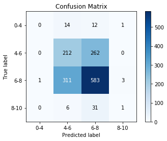

```python
# optional
#pip install scikit-plot
import scikitplot as skplt

skplt.metrics.plot_confusion_matrix(y_true=np.array(y_test), y_pred=knn.predict(x_test))
plt.show()
```

### Random Forest Classifier

```python
from sklearn.ensemble import RandomForestClassifier

rfc = RandomForestClassifier(n_estimators=13)
rfc = rfc.fit(x_train, y_train)

print metrics.accuracy_score(y_test, rfc.predict(x_test))
print "--------------------------------------------------------"
print metrics.confusion_matrix(y_test, rfc.predict(x_test))
print "--------------------------------------------------------"
print metrics.classification_report(y_test, rfc.predict(x_test))
```

```
0.7613082811412665
--------------------------------------------------------
[[  0  18   9   0]
 [  0 285 189   0]
 [  1 101 793   3]
 [  0   0  22  16]]
--------------------------------------------------------
             precision    recall  f1-score   support

        0-4       0.00      0.00      0.00        27
        4-6       0.71      0.60      0.65       474
        6-8       0.78      0.88      0.83       898
       8-10       0.84      0.42      0.56        38

avg / total       0.74      0.76      0.75      1437
```

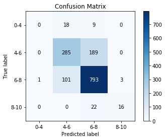

```python
# optional
#pip install scikit-plot
import scikitplot as skplt

skplt.metrics.plot_confusion_matrix(y_true=np.array(y_test), y_pred=rfc.predict(x_test))
plt.show()
```

## Feature Selection

### SelectKBest

```python
y = data.imdb_score_bin

# drop profit as since it has negative numbers and will not work for feature selection
x = data.drop(['imdb_score_bin', 'profit', 'imdb_score'], axis=1)
```

```python
X_new = SelectKBest(chi2, k=3).fit_transform(x, y)
```

```python
selector = SelectKBest(chi2, k=3).fit(x, y)
idxs_selected = selector.get_support(indices=True)
print idxs_selected

#num_voted_users 9
#gross 17
#budget 18
# director facebool like 3
#cast total facebook likes 10
```

```
[ 9 17 18]
```

```python
# evaluate the model by splitting into train (70%) and test sets (30%)
X_train, X_test, y_train, y_test = train_test_split(X_new, y, test_size=0.3, random_state=0)
#model2 = tree.DecisionTreeClassifier(criterion='entropy', max_depth=3,min_samples_leaf=5)
dt = tree.DecisionTreeClassifier()
dt.fit(X_train, y_train)

#Model evaluation
print metrics.accuracy_score(y_test, dt.predict(X_test))
print "--------------------------------------------------------"
print metrics.confusion_matrix(y_test, dt.predict(X_test))
print "--------------------------------------------------------"
print metrics.classification_report(y_test, dt.predict(X_test))
```

```
0.6604036186499652
--------------------------------------------------------
[[  2  17   8   0]
 [ 22 249 203   0]
 [ 10 188 681  19]
 [  0   0  21  17]]
--------------------------------------------------------
             precision    recall  f1-score   support

        0-4       0.06      0.07      0.07        27
        4-6       0.55      0.53      0.54       474
        6-8       0.75      0.76      0.75       898
       8-10       0.47      0.45      0.46        38

avg / total       0.66      0.66      0.66      1437
```

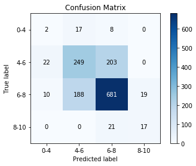

```python
# optional
#pip install scikit-plot
import scikitplot as skplt

skplt.metrics.plot_confusion_matrix(y_true=np.array(y_test), y_pred=dt.predict(X_test))
plt.show()
```

### Recursive Feature Selection

```python
model = LogisticRegression()
rfe = RFE(model, 4)
rfe = rfe.fit(x, y)

# Features sorted by their rank
pd.DataFrame({'feature':x.columns, 'importance':rfe.ranking_}).sort_values("importance", ascending=True).head(10)
```

|  | feature | importance |
| --- | --- | --- |
| 0 | oscar_wins | 1 |
| 1 | oscar_noms | 1 |
| 33 | Romance | 1 |
| 25 | Drama | 1 |
| 13 | color | 2 |
| 16 | aspect_ratio | 3 |
| 29 | Horror | 4 |
| 23 | Comedy | 5 |
| 32 | Mystery | 6 |
| 36 | Thriller | 7 |

```python
x_logistic = data[['oscar_wins', 'oscar_noms', 'Romance', 'Drama', 'color', 'Horror', 'Comedy', 'Mystery', 'Thriller', 'content_rating']]

rfc = RandomForestClassifier(n_estimators=20)
rfc = rfc.fit(x_train, y_train)

print metrics.accuracy_score(y_test, rfc.predict(x_test))
print "--------------------------------------------------------"
print metrics.confusion_matrix(y_test, rfc.predict(x_test))
print "--------------------------------------------------------"
print metrics.classification_report(y_test, rfc.predict(x_test))
```

```
0.7592205984690327
--------------------------------------------------------
[[  1  19   7   0]
 [  0 295 179   0]
 [  0 117 779   2]
 [  0   0  22  16]]
--------------------------------------------------------
             precision    recall  f1-score   support

        0-4       1.00      0.04      0.07        27
        4-6       0.68      0.62      0.65       474
        6-8       0.79      0.87      0.83       898
       8-10       0.89      0.42      0.57        38

avg / total       0.76      0.76      0.75      1437
```

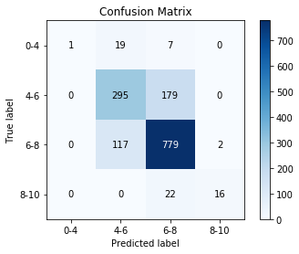

```python
# optional
#pip install scikit-plot
import scikitplot as skplt

skplt.metrics.plot_confusion_matrix(y_true=np.array(y_test), y_pred=rfc.predict(x_test))
plt.show()
```

# Clustering Analysis

### Determining K Value

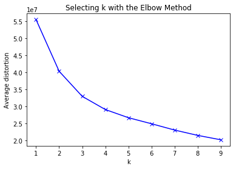

```python
from sklearn.metrics.pairwise import pairwise_distances_argmin
from scipy.spatial.distance import cdist
from sklearn import metrics
from sklearn.metrics import silhouette_samples, silhouette_score
import matplotlib.cm as cm

from sklearn.cluster import AgglomerativeClustering
from sklearn.cluster import ward_tree
from scipy.cluster.hierarchy import dendrogram, linkage, ward

from sklearn import tree

#The Elbow method

#https://www.packtpub.com/big-data-and-business-intelligence/mastering-machine-learning-scikit-learn#
#http://scikit-learn.org/stable/modules/clustering.html

K = range(1, 10)
meandistortions = []
for k in K:
    kmeans = KMeans(n_clusters=k)
    kmeans.fit(x)
    meandistortions.append(sum(np.min(cdist(x, kmeans.cluster_centers_, 'euclidean'), axis=1)) / x.shape[0])

plt.plot(K, meandistortions, 'bx-')
plt.xlabel('k')
plt.ylabel('Average distortion')
plt.title('Selecting k with the Elbow Method')
plt.show()
```

### K-Means Clustering

```python
from sklearn.cluster import KMeans

from sklearn.cluster import AgglomerativeClustering
from sklearn.metrics import pairwise_distances
```

```python
data.var()
```

```
oscar_wins                   5.941232e-01
oscar_noms                   7.457445e-01
duration                     4.369561e+02
director_facebook_likes      6.639379e+06
actor_1_facebook_likes       3.130794e+07
actor_2_facebook_likes       3.315856e+06
actor_3_facebook_likes       5.776311e+05
num_user_for_reviews         1.731330e+05
num_critic_for_reviews       1.741887e+04
num_voted_users              2.704321e+10
cast_total_facebook_likes    5.010898e+07
movie_facebook_likes         2.040796e+07
facenumber_in_poster         8.067713e+00
color                        2.542034e-02
title_year                   1.536092e+02
content_rating               7.819821e-01
aspect_ratio                 1.178579e-01
gross                        4.638469e+15
budget                       1.804909e+15
imdb_score                   9.791842e-01
profit                       2.713311e+15
Action                       1.922998e-01
Adventure                    1.747842e-01
Animation                    5.541823e-02
Biography                    5.468063e-02
Comedy                       2.467794e-01
Crime                        1.559796e-01
Drama                        2.491732e-01
Family                       1.253980e-01
Fantasy                      1.218345e-01
History                      3.385002e-02
Horror                       9.317700e-02
Music                        3.886882e-02
Musical                      3.287810e-02
Mystery                      9.712132e-02
Romance                      1.798513e-01
SciFi                        1.114653e-01
Sport                        4.249914e-02
Thriller                     2.116151e-01
War                          3.131851e-02
Western                      1.803786e-02
dtype: float64
```

```python
df = data
df = data.drop(['imdb_score_bin'], axis=1)

df_norm = (df - df.mean()) / (df.max() - df.min())
df_norm.head()
```

|  | oscar_wins | oscar_noms | duration | director_facebook_likes | actor_1_facebook_likes | actor_2_facebook_likes | actor_3_facebook_likes | num_user_for_reviews | num_critic_for_reviews | num_voted_users | cast_total_facebook_likes | movie_facebook_likes | facenumber_in_poster | color | title_year | content_rating | aspect_ratio | gross | budget | imdb_score | profit | Action | Adventure | Animation | Biography | Comedy | Crime | Drama | Family | … |
| --- | --- | --- | --- | --- | --- | --- | --- | --- | --- | --- | --- | --- | --- | --- | --- | --- | --- | --- | --- | --- | --- | --- | --- | --- | --- | --- | --- | --- | --- | --- |
| 0 | 0.313106 | -0.034864 | 0.231231 | 0.233801 | 0.010122 | 0.075068 | 0.277863 | 0.507511 | 0.607003 | 0.448714 | 0.051575 | 0.123503 | -0.017722 | 0.026096 | 0.121779 | -0.031246 | -0.020902 | 0.752332 | 0.628396 | 0.190899 | 0.575200 | 0.740292 | 0.774322 | -0.058873 | -0.058038 | -0.442797 | -0.193319 | -0.470355 | -0.146973 | … |
| 1 | -0.020227 | 0.465136 | 0.143393 | 0.018012 | -0.028959 | -0.016237 | -0.047980 | 0.939338 | 0.530161 | 0.156373 | -0.033704 | 0.013309 | 0.037833 | 0.026096 | 0.220544 | -0.031246 | 0.020679 | 0.602517 | -0.109922 | 0.109818 | -0.019423 | 0.740292 | 0.774322 | -0.058873 | -0.058038 | -0.442797 | -0.193319 | -0.470355 | -0.146973 | … |
| 2 | 0.090884 | -0.034864 | 0.285285 | 0.233801 | 0.185984 | 0.005502 | 0.015279 | 0.401895 | 0.178582 | 0.402840 | 0.166935 | 0.001221 | -0.017722 | 0.026096 | -0.026369 | -0.031246 | 0.020679 | 0.644308 | 0.513131 | 0.190899 | 0.502299 | -0.259708 | -0.225678 | -0.058873 | -0.058038 | -0.442797 | -0.193319 | 0.529645 | -0.146973 | … |
| 3 | -0.020227 | 0.090136 | 0.214339 | 0.181170 | 0.105524 | 0.418546 | 0.502582 | 0.255657 | 0.605951 | 0.510301 | 0.236346 | 0.001192 | 0.015611 | 0.026096 | 0.158816 | -0.031246 | -0.020902 | 0.605908 | 0.575437 | 0.231439 | 0.438728 | 0.740292 | 0.774322 | -0.058873 | -0.058038 | -0.442797 | -0.193319 | -0.470355 | -0.146973 | … |
| 4 | -0.020227 | 0.590136 | 0.089339 | 0.633801 | 0.057248 | 0.140285 | 0.176739 | 0.719981 | 0.751214 | 0.324538 | 0.099291 | -0.001706 | 0.015611 | 0.026096 | 0.195853 | -0.031246 | 0.020679 | 0.940398 | 0.653318 | 0.217926 | 0.766197 | 0.740292 | 0.774322 | -0.058873 | -0.058038 | -0.442797 | -0.193319 | -0.470355 | -0.146973 | … |

```python
df_norm.var()
```

```
oscar_wins                   0.007335
oscar_noms                   0.011652
duration                     0.004987
director_facebook_likes      0.018392
actor_1_facebook_likes       0.004136
actor_2_facebook_likes       0.006268
actor_3_facebook_likes       0.007292
num_user_for_reviews         0.005401
num_critic_for_reviews       0.019301
num_voted_users              0.006744
cast_total_facebook_likes    0.005165
movie_facebook_likes         0.000481
facenumber_in_poster         0.000996
color                        0.025420
title_year                   0.023412
content_rating               0.086887
aspect_ratio                 0.000548
gross                        0.005287
budget                       0.017516
imdb_score                   0.017881
profit                       0.003501
Action                       0.192300
Adventure                    0.174784
Animation                    0.055418
Biography                    0.054681
Comedy                       0.246779
Crime                        0.155980
Drama                        0.249173
Family                       0.125398
Fantasy                      0.121835
History                      0.033850
Horror                       0.093177
Music                        0.038869
Musical                      0.032878
Mystery                      0.097121
Romance                      0.179851
SciFi                        0.111465
Sport                        0.042499
Thriller                     0.211615
War                          0.031319
Western                      0.018038
dtype: float64
```

#### Clustering analysis (k=2)

```python
k_means = KMeans(init='k-means++', n_clusters=2, random_state=0)
```

```python
k_means.fit(df_norm)
```

```
KMeans(algorithm='auto', copy_x=True, init='k-means++', max_iter=300,
    n_clusters=2, n_init=10, n_jobs=1, precompute_distances='auto',
    random_state=0, tol=0.0001, verbose=0)
```

```python
#clustering results
k_means.labels_
```

```
array([0, 0, 0, ..., 1, 0, 1], dtype=int32)
```

```python
#cluster centroids or centers
k_means.cluster_centers_
```

```
array([[ 7.13362535e-03,  8.80634193e-03,  2.22307065e-02,
         1.45982949e-02,  9.99124423e-03,  9.14632912e-03,
         6.09393280e-03,  1.72845565e-02,  3.23799681e-02,
         1.29012126e-02,  1.15110642e-02,  5.72576922e-04,
        -4.16133500e-03, -5.83932635e-03,  7.54694227e-03,
         1.02138984e-01,  4.53170878e-03,  4.77481052e-04,
         1.05451891e-02,  2.25700569e-02, -2.01347620e-03,
         1.24286119e-01, -2.59863076e-02, -5.50250177e-02,
         3.73837376e-02, -4.04705921e-01,  7.17825468e-02,
         1.32184532e-01, -1.31582325e-01, -5.30820831e-02,
         2.57195436e-02,  6.57140493e-02, -4.33328701e-03,
        -2.36406166e-02,  6.22426644e-02, -7.73200870e-02,
         4.07601768e-02, -5.22177712e-03,  2.35471648e-01,
         1.80449201e-02,  4.71419472e-03],
       [-8.46202295e-03, -1.04462267e-02, -2.63704272e-02,
        -1.73167359e-02, -1.18517772e-02, -1.08495250e-02,
        -7.22872265e-03, -2.05032233e-02, -3.84096472e-02,
        -1.53036291e-02, -1.36546124e-02, -6.79200100e-04,
         4.93624358e-03,  6.92670433e-03, -8.95230623e-03,
        -1.21158932e-01, -5.37558700e-03, -5.66395826e-04,
        -1.25088756e-02, -2.67729703e-02,  2.38841837e-03,
        -1.47430226e-01,  3.08253826e-02,  6.52715750e-02,
        -4.43452004e-02,  4.80068776e-01, -8.51496300e-02,
        -1.56799452e-01,  1.56085104e-01,  6.29668343e-02,
        -3.05089429e-02, -7.79510790e-02,  5.14021586e-03,
         2.80428856e-02, -7.38332655e-02,  9.17183505e-02,
        -4.83503877e-02,  6.19415735e-03, -2.79320317e-01,
        -2.14051791e-02, -5.59205480e-03]])
```

```python
#To add cluster label into the dataset as a column
df1 = pd.DataFrame(k_means.labels_, columns = ['cluster'])
df1.head()
```

|  | cluster |
| --- | --- |
| 0 | 0 |
| 1 | 0 |
| 2 | 0 |
| 3 | 0 |
| 4 | 0 |

```python
df = df.reset_index(drop=True)
df1 = df1.reset_index(drop=True)

df2 = df.join(df1)
df2.head()
```

|  | oscar_wins | oscar_noms | duration | director_facebook_likes | actor_1_facebook_likes | actor_2_facebook_likes | actor_3_facebook_likes | num_user_for_reviews | num_critic_for_reviews | num_voted_users | cast_total_facebook_likes | movie_facebook_likes | facenumber_in_poster | color | title_year | content_rating | aspect_ratio | gross | budget | imdb_score | profit | Action | Adventure | Animation | Biography | Comedy | Crime | Drama | Family | … |
| --- | --- | --- | --- | --- | --- | --- | --- | --- | --- | --- | --- | --- | --- | --- | --- | --- | --- | --- | --- | --- | --- | --- | --- | --- | --- | --- | --- | --- | --- | --- |
| 0 | 3 | 0 | 178 | 5400 | 5700 | 3100 | 2900 | 3184 | 723 | 1004105 | 11700 | 26000 | 0 | 1 | 2009 | 2 | 1.78 | 760507625 | 237000000 | 7.8 | 523507625 | 1 | 1 | 0 | 0 | 0 | 0 | 0 | 0 | … |
| 1 | 0 | 4 | 152 | 1300 | 2300 | 1000 | 0 | 5629 | 650 | 418687 | 3300 | 3300 | 5 | 1 | 2017 | 2 | 2.39 | 620181382 | 0 | 7.2 | 0 | 1 | 1 | 0 | 0 | 0 | 0 | 0 | 0 | … |
| 2 | 1 | 0 | 194 | 5400 | 21000 | 1500 | 563 | 2586 | 316 | 912242 | 23063 | 810 | 0 | 1 | 1997 | 2 | 2.39 | 659325379 | 200000000 | 7.8 | 459325379 | 0 | 0 | 0 | 0 | 0 | 0 | 1 | 0 | … |
| 3 | 0 | 1 | 173 | 4400 | 14000 | 11000 | 4900 | 1758 | 722 | 1127434 | 29900 | 804 | 3 | 1 | 2012 | 2 | 1.78 | 623357910 | 220000000 | 8.1 | 403357910 | 1 | 1 | 0 | 0 | 0 | 0 | 0 | 0 | … |
| 4 | 0 | 5 | 136 | 13000 | 9800 | 4600 | 2000 | 4387 | 860 | 755440 | 16400 | 207 | 3 | 1 | 2015 | 2 | 2.39 | 936662225 | 245000000 | 8.0 | 691662225 | 1 | 1 | 0 | 0 | 0 | 0 | 0 | 0 | … |

```python
df2.groupby(['cluster']).size()
```

```
cluster
0    2599
1    2191
dtype: int64
```

```python
df2.groupby('cluster').mean()
```

| cluster | oscar_wins | oscar_noms | duration | director_facebook_likes | actor_1_facebook_likes | actor_2_facebook_likes | actor_3_facebook_likes | num_user_for_reviews | num_critic_for_reviews | num_voted_users | cast_total_facebook_likes | movie_facebook_likes | facenumber_in_poster | color | title_year | content_rating | aspect_ratio | gross | budget | imdb_score | profit | Action | Adventure | Animation | Biography | Comedy | Crime | Drama | Family | … |
| --- | --- | --- | --- | --- | --- | --- | --- | --- | --- | --- | --- | --- | --- | --- | --- | --- | --- | --- | --- | --- | --- | --- | --- | --- | --- | --- | --- | --- | --- | --- |
| 0 | 0.246249 | 0.349365 | 116.135821 | 1235.145056 | 5688.644094 | 1583.811081 | 481.256252 | 408.335514 | 177.107734 | 131383.547518 | 7753.711427 | 676.366295 | 1.220469 | 0.968065 | 1999.747210 | 2.400154 | 2.153113 | 5.627401e+07 | 3.866988e+07 | 6.554367 | 1.532779e+07 | 0.383994 | 0.199692 | 0.003848 | 0.095421 | 0.038092 | 0.265102 | 0.602539 | 0.015391 | … |
| 1 | 0.105888 | 0.195345 | 101.749886 | 628.759471 | 3788.301232 | 1123.906435 | 362.684619 | 194.381105 | 109.857599 | 74902.985395 | 5274.892287 | 418.500228 | 2.039251 | 0.980831 | 1998.410771 | 1.730260 | 2.007773 | 5.529625e+07 | 3.126952e+07 | 6.189229 | 1.920323e+07 | 0.112277 | 0.256504 | 0.124144 | 0.013692 | 0.922866 | 0.108170 | 0.313555 | 0.303058 | … |

### Hierarchical Clustering Algorithm

```python
from sklearn.cluster import KMeans
from sklearn.cluster import AgglomerativeClustering
from sklearn.cluster import ward_tree
from scipy.cluster.hierarchy import dendrogram, linkage, ward

from sklearn.metrics import pairwise_distances
```

```python
np.random.seed(1) # setting random seed to get the same results each time.

agg= AgglomerativeClustering(n_clusters=4, linkage='ward').fit(df_norm)
agg.labels_
```

```
array([0, 0, 1, ..., 1, 0, 0])
```

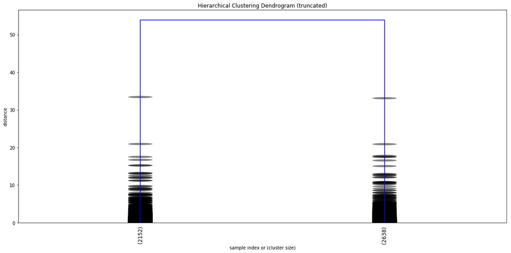

```python
plt.figure(figsize=(16,8))

plt.title('Hierarchical Clustering Dendrogram (truncated)')
plt.xlabel('sample index or (cluster size)')
plt.ylabel('distance')

linkage_matrix = ward(df_norm)
dendrogram(linkage_matrix,
           truncate_mode='lastp',  # show only the last p merged clusters
           p=2,  # show only the last p merged clusters
           #show_leaf_counts=False,  # otherwise numbers in brackets are counts
           leaf_rotation=90.,
           leaf_font_size=12.,
           show_contracted=True,  # to get a distribution impression in truncated branches
           orientation="top")
plt.tight_layout() # fixes margins
```

# Summary

There are a few variables that can predict the success of a movie. Who the director is and who is cast in the movie have a huge impact on a movie's profit margin. The genre, plot, and movie reviews also have impact on the movies success.

For example, when looking at the word frequency of the plot keywords, it is easy to see that the superhero movies, possibly with villains and aliens, produced profits greater than $100,000,000. Movies with drama, adventure, and comedy are sure to be a success.

Movies directed by Steven Spielberg have brought in the most profits. The top five directors in terms of overall movie profit are:

1. Steven Spielberg
2. George Lucas
3. James Cameron
4. Chris Columbus
5. Christopher Nolan

In general, who is cast in the movie can also help to predict movie success. The top actors in terms of overall movie profits are:

1. Tom Hanks
2. Robert Downey Jr.
3. Harrison Ford
4. Carrie Fisher
5. Scarlett Johansson

It is clear that a few variables keep coming up as important factors in predicting movie success. For example, we can see a correlation between a movie's IMDB score and the following predictors:

1. Oscar Wins
2. Oscar Nominations
3. Duration
4. Actor 1 Facebook Likes
5. Number of users for reviews
6. Number of critics for reviews
7. Number of users voted
8. Cast and movie facebook likes
9. Gross income and Profit

It seems that a majority of factors revolve around the number of voters\critics and the number of facebook likes. This makes sense due to the nature of the IMDB score, a user generated and populated score explains why social media and number or vote\reviews affect the IMDB score. If we ignore those, we are left with Oscar Wins\Noms, Duration and Gross income\profit.

A theory could be that a movie's success is more a measure of it's marketing ability than other factors.

**Modeling/Evaluation:**

Regression modeling may not be the best method of predicting the IMDB score. In fact, calculating the k-value shows that the accuracy of the model increases as I include more predictors. This make sense on some level, the more factors I include the more accurate I can predict success. However, it doesn't help us to narrow down which predictors (currently available) are likely to predict a movie's success.